# R Notebook

DA5030

Shaikh, Saoud

Spring 2025

```r
# TODO: Feature: Auto-install all  your libraries as a code block, could be pretty cool.

# TODO: VERY IMPORTANT: Use Project reference doc to play around with your code and annotate, explain things in a way that you can understand.

# TODO: Add table of contents so user can basically navigate to any section in the document.

# TODO: Keep your changes as superficial and quick as possible, move onto applications with a bare minimum resume and then keep editing as needed.
```

```r
# TODO: Project writer struggled with time constraints, so had to balance project with getting a finished deliverable.

# Polishing Note: Now that this will be on my github page, I need to demonstrate how a tentative rushed project can be transformed into a github project worth demonstrating.
```

# 1 / Business Understanding

Customer retention may often be a very important factor for Telecommunication companies, knowing if a customer is likely to stay with the company or not is a very valuable factor that may dramatically affect company profits and revenue.

The phrase “Customer is King” may be often thrown around very often. A better variation of this would be “Customer experience is king”. For this project, I want to investigate how different factors of customer experience can be used to predict churn in telecom companies.

```r
# If I remember this right, churn prediction would be a "Yes or No" value which determines whether the customer is retained or not.
```

In a more practical context, the goal is to use previous data to assist a hypothetical telecom company’s marketing team predict if they will retain a customer or not using different demographic factors such as age, their usage of telecom plans, and different indicators of user experience such as how active a customer is, their frequency of use…etc.

In the future, this could possibly be used to create a customer flagging system to help identify customers they are at the risk of losing and direct their customer service team.

Of course I’d have to use CRISP-DM, but the framework can be a bit rigid at times. One question I was considering is that when I’m exploring data I may find information that I may want to immediately act on, such as missing values or outlier imputation. Instead, when I’m following this framework I might have to note down any data quality issues in the data understanding section, then act on them in the Data preparation section.

- Build and evaluate a deployable ensemble classification model to predict customer churn, this is the biggest priority. My models will be based on KNN, Logistic Regression, and Random Forest
- If the model does not deploy well, I want to understand what went wrong and identify areas of improvement.

```r
# TODO: Review requires me to ensure that this project is in a finished marketable state, I'll try my best to fix any areas of improvement as needed.
```

- I want to deepen my understanding of classification techniques in the context of machine learning.

# 2 / Data Understanding

I will be working with the “Iranian Churn” dataset.

Want to know more about the dataset? You can find it at the UCI machine learning repository. Refer to 7 / References for more information.

### Data loading

For a reproducible workflow, it may be best to have a reliable URL that can be accessed by anyone. One workaround is to upload a file on google drive and share it from there. My concern is that this method can be a bit error prone, and I don’t find google drive file hosting reliable. My solution? I opted to use a public github repo with a raw file that would be easy and straightforward to load.

```r
# TODO: Review the link that you posted to make sure that it is future-proof for any later glimpses.
```

```r
# This URL MUST stay online!
gitURL <- "https://raw.githubusercontent.com/shaikhprograms/neus25mlhosting/refs/heads/main/Customer%20Churn.csv"

df <- read.csv(gitURL, header = TRUE)
```

Did our data load properly using the above commands? Let’s check

|  | Call..Failure | Complains | Subscription..Length | Charge..Amount | Seconds.of.Use | Frequency.of.use | Frequency.of.SMS | Distinct.Called.Numbers | Age.Group | Tariff.Plan | Status | Age | Customer.Value | Churn |
| --- | --- | --- | --- | --- | --- | --- | --- | --- | --- | --- | --- | --- | --- | --- |
| 1 | 8 | 0 | 38 | 0 | 4370 | 71 | 5 | 17 | 3 | 1 | 1 | 30 | 197.640 | 0 |
| 2 | 0 | 0 | 39 | 0 | 318 | 5 | 7 | 4 | 2 | 1 | 2 | 25 | 46.035 | 0 |
| 3 | 10 | 0 | 37 | 0 | 2453 | 60 | 359 | 24 | 3 | 1 | 1 | 30 | 1536.520 | 0 |
| 4 | 10 | 0 | 38 | 0 | 4198 | 66 | 1 | 35 | 1 | 1 | 1 | 15 | 240.020 | 0 |
| 5 | 3 | 0 | 38 | 0 | 2393 | 58 | 2 | 33 | 1 | 1 | 1 | 15 | 145.805 | 0 |
| 6 | 11 | 0 | 38 | 1 | 3775 | 82 | 32 | 28 | 3 | 1 | 1 | 30 | 282.280 | 0 |

It did! We’re all set, now we need to work on further exploring our dataset and gaining a better understanding of it.

### Has this dataset been analyzed before?

Yes, but not in the context of classification modelling, a previous analysis of the dataset’s structure by Jeffery Uzoukwu (Uzoukwu, 2024) that I initially missed exists. For transparency’s sake I could talk about what he did differently. His analysis was in the context of bringing out business insights, and focused on analyzing trends between each feature and the churn rate.

Some of our analysis may overlap, such as his glance over the data structure, with simple factors such as the data histograms and summary statistics, missing values…etc. also being similar.

Our data analysis WILL diverge though, My analysis differs in terms of the motive.

My project is a modelling one, thus the insights I need from the data are different. For example, his histogram analysis is rudimentary, while I would need to analyze the data’s very shape and structure in context of the algorithms that I’m working with.

I would need to better understand the data’s distribution, analyze normality for example and what it means for my algorithms. My analysis would be done in context to the three different machine learning models I’m working with to determine what data shaping I have to perform, and follow a CRISP-DM approach instead.

### Data Quality

Let’s examine the dataset. Do understand that the iranian churn dataset is best examined in context of the data key provided with the dataset.

Why? Because the data’s structure doesn’t make ordinal and binary variables immediately clear at first glance in R. More on this later. I extracted this key from UCI machine learning repository and rewrote it so that it would be easier to understand how the data is structured.

```
#### Numerics
Call Failures: number of call failures
Subscription Length: total months of subscription
Seconds of Use: total seconds of calls
Frequency of use: total number of calls
Frequency of SMS: total number of text messages
Distinct Called Numbers: total number of distinct phone calls
Customer Value: Arbitrary metric that shows the calculated value of a customer.

#### Binaries
Complains: binary (0: No complaint, 1: complaint)
Tariff Plan: binary (1: Pay as you go, 2: contractual)
Status: binary(1: active, 2: non-active)

#### Ordinals
Age Group: ordinal attribute (1: younger age, 5: older age)
Charge Amount: Ordinal attribute (0: lowest amount, 9: highest amount)
Age: How old the customer is, it's not mentioned in the original key, I had to add it here. (15:youngest, 55: oldest)

#### Our Target
Churn: binary (1: churn, 0: non-churn) - Class label

(UCI Machine Learning Repository, 2020)
```

```
## 'data.frame':    3150 obs. of  14 variables:
##  $ Call..Failure          : int  8 0 10 10 3 11 4 13 7 7 ...
##  $ Complains              : int  0 0 0 0 0 0 0 0 0 0 ...
##  $ Subscription..Length   : int  38 39 37 38 38 38 38 37 38 38 ...
##  $ Charge..Amount         : int  0 0 0 0 0 1 0 2 0 1 ...
##  $ Seconds.of.Use         : int  4370 318 2453 4198 2393 3775 2360 9115 13773 4515 ...
##  $ Frequency.of.use       : int  71 5 60 66 58 82 39 121 169 83 ...
##  $ Frequency.of.SMS       : int  5 7 359 1 2 32 285 144 0 2 ...
##  $ Distinct.Called.Numbers: int  17 4 24 35 33 28 18 43 44 25 ...
##  $ Age.Group              : int  3 2 3 1 1 3 3 3 3 3 ...
##  $ Tariff.Plan            : int  1 1 1 1 1 1 1 1 1 1 ...
##  $ Status                 : int  1 2 1 1 1 1 1 1 1 1 ...
##  $ Age                    : int  30 25 30 15 15 30 30 30 30 30 ...
##  $ Customer.Value         : num  198 46 1537 240 146 ...
##  $ Churn                  : int  0 0 0 0 0 0 0 0 0 0 ...
```

Interesting! We don’t have any explicitly categorical variables here in this case. Instead, categoricals are ordinally encoded. This makes the dataset a good choice for KNN. With only 13 variables, the dataset isn’t highly dimensional. I anticipate that we might have to come up with a derived feature though.

I just want to be sure about the classes though.

```
##           Call..Failure               Complains    Subscription..Length
##               "integer"               "integer"               "integer"
##          Charge..Amount          Seconds.of.Use        Frequency.of.use
##               "integer"               "integer"               "integer"
##        Frequency.of.SMS Distinct.Called.Numbers               Age.Group
##               "integer"               "integer"               "integer"
##             Tariff.Plan                  Status                     Age
##               "integer"               "integer"               "integer"
##          Customer.Value                   Churn
##               "numeric"               "integer"
```

As expected. Notice the overwhelming presence of numeric and integer fields, The automatic inspection above would not actually reflect reality and what the previous data key mentioned. Our data key and actual inspection of our data according to this key is the best way to proceed. Anyways, 3150 rows of observations seems like a fairly appropriate length of data for our modelling efforts, and our dataset loads fairly fast in terms of performance.

Let’s take a quick look at the distribution of our data.

```
##  Call..Failure      Complains       Subscription..Length Charge..Amount
##  Min.   : 0.000   Min.   :0.00000   Min.   : 3.00        Min.   : 0.0000
##  1st Qu.: 1.000   1st Qu.:0.00000   1st Qu.:30.00        1st Qu.: 0.0000
##  Median : 6.000   Median :0.00000   Median :35.00        Median : 0.0000
##  Mean   : 7.628   Mean   :0.07651   Mean   :32.54        Mean   : 0.9429
##  3rd Qu.:12.000   3rd Qu.:0.00000   3rd Qu.:38.00        3rd Qu.: 1.0000
##  Max.   :36.000   Max.   :1.00000   Max.   :47.00        Max.   :10.0000
##  Seconds.of.Use  Frequency.of.use Frequency.of.SMS Distinct.Called.Numbers
##  Min.   :    0   Min.   :  0.00   Min.   :  0.00   Min.   : 0.00
##  1st Qu.: 1391   1st Qu.: 27.00   1st Qu.:  6.00   1st Qu.:10.00
##  Median : 2990   Median : 54.00   Median : 21.00   Median :21.00
##  Mean   : 4472   Mean   : 69.46   Mean   : 73.17   Mean   :23.51
##  3rd Qu.: 6478   3rd Qu.: 95.00   3rd Qu.: 87.00   3rd Qu.:34.00
##  Max.   :17090   Max.   :255.00   Max.   :522.00   Max.   :97.00
##    Age.Group      Tariff.Plan        Status           Age     Customer.Value
##  Min.   :1.000   Min.   :1.000   Min.   :1.000   Min.   :15   Min.   :   0.0
##  1st Qu.:2.000   1st Qu.:1.000   1st Qu.:1.000   1st Qu.:25   1st Qu.: 113.8
##  Median :3.000   Median :1.000   Median :1.000   Median :30   Median : 228.5
##  Mean   :2.826   Mean   :1.078   Mean   :1.248   Mean   :31   Mean   : 471.0
##  3rd Qu.:3.000   3rd Qu.:1.000   3rd Qu.:1.000   3rd Qu.:30   3rd Qu.: 788.4
##  Max.   :5.000   Max.   :2.000   Max.   :2.000   Max.   :55   Max.   :2165.3
##      Churn
##  Min.   :0.0000
##  1st Qu.:0.0000
##  Median :0.0000
##  Mean   :0.1571
##  3rd Qu.:0.0000
##  Max.   :1.0000
```

#### Class Balance

Before we do anything, I want to analyze my Class balance, this is important because an imbalanced class could cause problems with bias towards a specific class variable if it’s overrepresented in my dataset.

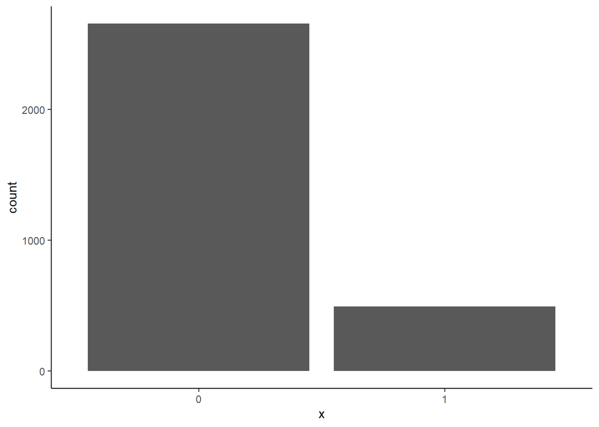

This is…unfortunate. Notice what’s wrong? The negative class, in this case 0, is overrepresented. This will create bias which I a nticipate I’ll have to fix. One possible technique I could use is SMOTE. More on that soon in the Data preparation section.

I anticipate that KNN and Random Forest would struggle with this class balance due to bias. This wouldn’t make them a bad choice for the dataset though! Tuning the k parameter could also be another solution to optimize our model too.

What about the other columns?

Let’s go through a two pronged approach, first we analyze the categorical variables to see if they’re well distributed or not. This could affect our application of min-max normalization on ordinal variables.

#### Categoricals - Ordinal

Let’s analyze the distribution of ordinal variables first. One important point with my approach to this dataset is that I’m relying on my dataset key to understand variables as I work with them.

```
## Age group
```

```
##
##    1    2    3    4    5
##  123 1037 1425  395  170
```

```
## Charge Amount
```

```
##
##    0    1    2    3    4    5    6    7    8    9   10
## 1768  617  395  199   76   30   11   14   19   14    7
```

```
## Status
```

```
##
##    1    2
## 2368  782
```

Ah, we have an issue here. Both of these ordinal variables are on different scales. This spells out issues for KNN, but we understand that min-max normalization can solve this issue. Both ordinal values have a fair amount of variance, so we shouldn’t remove them yet. One consideration with KNN is that these ordinal variables would be treated as continuous. I would rather NOT one hot encode these variables as that would affect model performance, min max normalization seems like the way to go. There’s something Interesting I noticed about the data distribution for charge amount. As you increase how much customers are charged, the actual amount of customers decreases. I wonder how this would look like on a plot.

```r
# See? I knew the quickplot function would come in handy.
cat("Plot for Charge amount frequency")
```

```
## Plot for Charge amount frequency
```

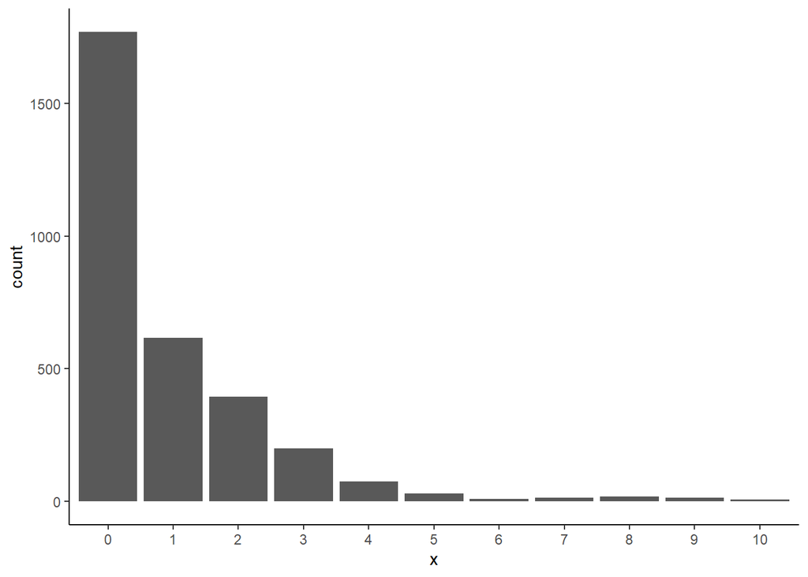

```r
gg.quickplot(factor(df$Charge..Amount), df)
```

#### Categoricals - Binaries

Let’s analyze the distribution of binary variables.

```
## Tariff Plan
```

```
##
##    1    2
## 2905  245
```

[output not shown]

```
##
##    0    1
## 2909  241
```

Of course, to follow CRISP DM I’d rather make all the necessary changes and preparations in 3 / Data Preparation.

#### Missing values

Do we have any missing values? Let’s check. Of course, the original dataset doesn’t have any missing values, but it doesn’t hurt to confirm.

```
##           Call..Failure               Complains    Subscription..Length
##                       0                       0                       0
##          Charge..Amount          Seconds.of.Use        Frequency.of.use
##                       0                       0                       0
##        Frequency.of.SMS Distinct.Called.Numbers               Age.Group
##                       0                       0                       0
##             Tariff.Plan                  Status                     Age
##                       0                       0                       0
##          Customer.Value                   Churn
##                       0                       0
```

No missing values. When we reach the data shaping stage, I’ll generate two datasets to work on, one will have missing values added in, generated at random while the other dataset will not have missing values present. More on that soon. See 3 / Data Preparation for more info.

```r
# TODO: Investigate if missing values were added properly, I believe this section was skipped.

# TODO: Keep a section to indicate which algorithms were used, notice that there's an inconsistency between the two in the beginning.
```

#### Outlier identification

Identifying outliers is especially important because of the three algorithms that we’re working with, KNN is the most sensitive to outliers. Logistic regression too, to a certain extent. Random forest is a bit more robust but it wouldn’t hurt to deal with outliers for all three algorithms and datasets.

Usually I use the z-score method because I find it to be the most reliable, we can use a threshold of about 3.0 as usual. One topic I want to investigate further in the future is how changing the z score threshold for outlier analysis would affect our models.

As with my previous work, we specify numerics first. I’ll use this for reference. All other fields are technically categoricals. Let’s use an old favorite function of mines to check outliers.

```
#### Numerics
Call Failures: number of call failures
Subscription Length: total months of subscription
Seconds of Use: total seconds of calls
Frequency of use: total number of calls
Frequency of SMS: total number of text messages
Distinct Called Numbers: total number of distinct phone calls
```

```r
# Creating a vector of names which I can iterate through to find outliers.
df.nums <- c("Call..Failure", "Subscription..Length", "Seconds.of.Use", "Frequency.of.use", "Frequency.of.SMS", "Distinct.Called.Numbers")

outlier.check <- function(x){
 m <- mean(x, na.rm = TRUE)
 s <- sd(x, na.rm = TRUE)

z.score <- abs((x - m) /  s)

 outlier <- which(z.score > 3.0)

 return(length(outlier))
}

apply(df[,df.nums], 2, outlier.check)
```

```
##           Call..Failure    Subscription..Length          Seconds.of.Use
##                      40                      26                       1
##        Frequency.of.use        Frequency.of.SMS Distinct.Called.Numbers
##                      24                      66                      57
```

Interesting, notice the sheer scale of outliers? Seconds of use has the fewest outliers while Frequency of SMS has the greatest.

I wanted to analyze Frequency of SMS on a boxplot just to understand this distribution better and how it relates to z score outliers for example. We recall that R’s base boxplots use IQR as their outlier criteria.

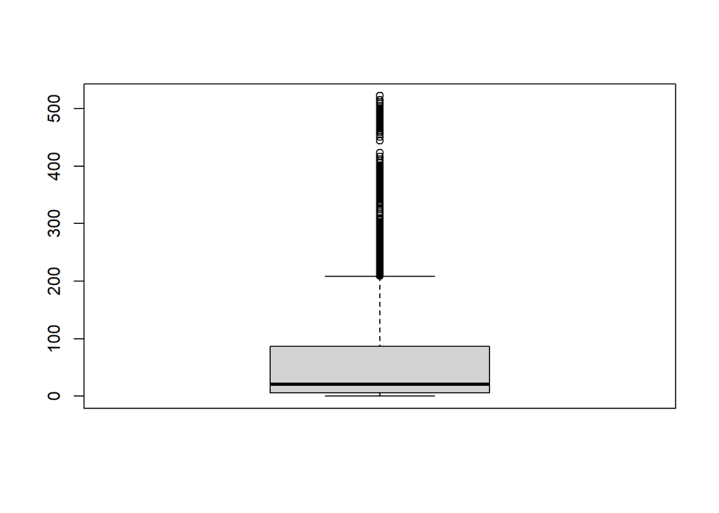

```
## using IQR, outliers for the SMS freq are 368
```

Interesting, notice how the IQR method gives us a larger scale of outliers? In this scale I believe R’s plot uses 1.5 IQR above or below as our threshold.

#### Correlation analysis

Remember, KNN is non-parametric so we’re not necessarily normalizing things for KNN. It’s more that we’re changing the scale. Our logistic regression algorithm does NOT assume normality, but of course as I’ve said before if our continuous data does not follow a similar distribution then normalizing our data would be required. Let’s take a peek at what our continuous features looks like.

Let’s analyze our dataset for multicollinearity to simplify our dataset.

```
##                         Call..Failure    Complains Subscription..Length
## Call..Failure             1.000000000  0.152878751          0.169737274
## Complains                 0.152878751  1.000000000         -0.020285693
## Subscription..Length      0.169737274 -0.020285693          1.000000000
## Charge..Amount            0.589028007 -0.033947650          0.078789350
## Seconds.of.Use            0.501606588 -0.104951779          0.124617629
## Frequency.of.use          0.573349363 -0.090774216          0.106533935
## Frequency.of.SMS         -0.022282384 -0.111632561          0.076317768
## Distinct.Called.Numbers   0.504057739 -0.058199351          0.092008969
## Age.Group                 0.050406294  0.019975935          0.021453354
## Tariff.Plan               0.192285474  0.001139618         -0.159679745
## Status                   -0.114644547  0.271405253          0.142840891
## Age                       0.041757649  0.003298017         -0.002429696
## Customer.Value            0.121225478 -0.132895322          0.109564756
## Churn                    -0.008987368  0.532052962         -0.032587894
##                         Charge..Amount Seconds.of.Use Frequency.of.use
## Call..Failure               0.58902801     0.50160659       0.57334936
## Complains                  -0.03394765    -0.10495178      -0.09077422
## Subscription..Length        0.07878935     0.12461763       0.10653394
## Charge..Amount              1.00000000     0.44673835       0.37909589
## Seconds.of.Use              0.44673835     1.00000000       0.94648923
## Frequency.of.use            0.37909589     0.94648923       1.00000000
## Frequency.of.SMS            0.09153336     0.10212319       0.10001921
## Distinct.Called.Numbers     0.41519790     0.67653630       0.73611353
## Age.Group                   0.27967884     0.02006038      -0.03254386
## Tariff.Plan                 0.32423241     0.13359296       0.20645228
## Status                     -0.35626867    -0.46061814      -0.45475181
## Age                         0.27895523     0.02084287      -0.02834981
## Customer.Value              0.16942771     0.41508724       0.40157246
## Churn                      -0.20230536    -0.29893454      -0.30333734
##                         Frequency.of.SMS Distinct.Called.Numbers    Age.Group
## Call..Failure                -0.02228238              0.50405774  0.050406294
## Complains                    -0.11163256             -0.05819935  0.019975935
## Subscription..Length          0.07631777              0.09200897  0.021453354
## Charge..Amount                0.09153336              0.41519790  0.279678836
## Seconds.of.Use                0.10212319              0.67653630  0.020060375
## Frequency.of.use              0.10001921              0.73611353 -0.032543860
## Frequency.of.SMS              1.00000000              0.07965044 -0.053718634
## Distinct.Called.Numbers       0.07965044              1.00000000  0.020941328
## Age.Group                    -0.05371863              0.02094133  1.000000000
```

[output cut: 20 more lines]

```
##                                Churn
## Call..Failure           -0.008987368
## Complains                0.532052962
## Subscription..Length    -0.032587894
## Charge..Amount          -0.202305363
## Seconds.of.Use          -0.298934544
## Frequency.of.use        -0.303337343
## Frequency.of.SMS        -0.220753640
## Distinct.Called.Numbers -0.278866867
## Age.Group               -0.014550192
## Tariff.Plan             -0.105852944
## Status                   0.498975611
## Age                     -0.017704845
## Customer.Value          -0.289144238
## Churn                    1.000000000
```

#### Outcomes from correlation Analysis

Here’s the beauty of correlation analysis. I believe that it gives you an idea of the shape of your dataset and uncover relationships in a way that you normally wouldn’t, there’s so much information I managed to mine from the correlation analysis. What do we notice in this case?

- In a context such as this, all of our predictors are NOT independent. Even the predictors that do not show high colinearity do show at least some correlation between each other. This is to be expected of course, since our data is very interconnected.
- Seconds of use is highly correlated with frequency of use(>0.90), they’re fairly similar features. No particular explanation would help so we could remove the feature with the least variance.
- frequency of SMS is colinear with customer value. In this case it may be better to remove customer value, because it’s an arbitrary feature without much explanation to it. What drives customer value? Nobody knows. From the data key: “The calculated value of customer”. If we had the formula for this calculation the feature could’ve been useful but a lack of explainability compared to frequency of SMS makes this a candidate for removal.
- We realized why, in terms of data quality data keys can be unreliable. The variable “Age” was multicollinear with Age Group (>0.90) . Nowhere in the actual key or variable information for our dataset was “Age” mentioned, and I would have missed it if it were not for multicollinearity analysis. The lesson? Don’t take data information for granted, always analyze thoroughly!

```
## Age
```

```
##
##   15   25   30   45   55
##  123 1037 1425  395  170
```

```
## Age group
```

```
##
##    1    2    3    4    5
##  123 1037 1425  395  170
```

This could either be an error by the data creator or just a way for them to keep track of the Age column, therefore Age group must be removed.

- There are two predictors that have the highest correlation with Churn. These are Status() and Complains.

Every bit of insight that we get here is important for the Data Preparation step of course because it guides our analysis.

#### Data Distribution analysis (Histograms)

Histograms are an important tool for analyzing numeric fields. You’ll notice that I left the histogram analysis for numeric columns for the end of our Data analysis section, this is because of the slightly different context I wanted to use pairs.panels in. Usually we would use it to analyze correlation, but that would slow our data processing down and that function becomes somewhat of a mess when you analyze everything at once.

You’ll notice we already analyzed most of the discrete(non-continuous) columns for correlation, so we can use pairs.panels to lower the load on the pairs.panels function when it loads histograms for our data. Why pairs.panels? Well, if we used a histogram for each column manually then it would take up a lot of processing when we knit our file! We’re not really interested with how these features correlate with churn anymore because we’ve already analyzed correlations and addressed colinearity.

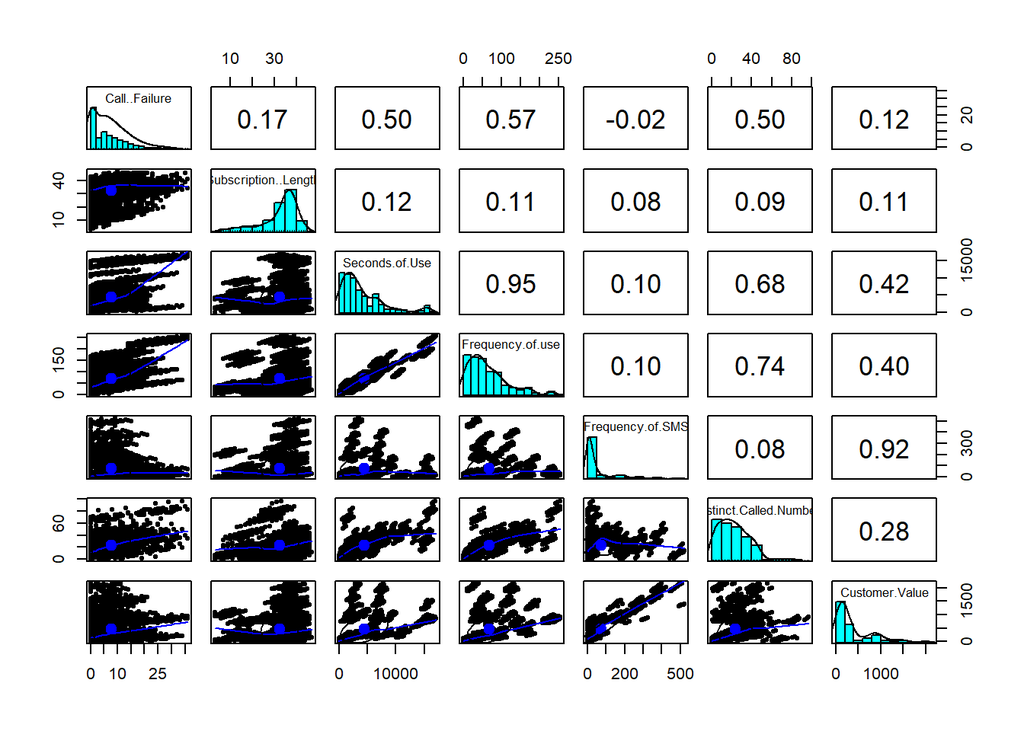

This shows some interesting trends for our numeric fields. Namely, subscription length is much closer to a normal distribution compared to the other numeric columns. Furthermore, I feel more justified in using KNN for our dataset now that I notice that the numeric columns have a somewhat similar skew or distribution except for subscription length, of course not too similar but it’s slightly noticeable. Then again, I recall that min-max normalization will keep our data on a similar scale anyways.

I also anticipate that for logistic regression, we expect our data set to at least have a reasonably normal distribution. When we finish most of our modelling steps, I’d prefer to keep our data normalized.

Now to move on to data preparation.

# 3 / Data Preparation

```r
#TODO: UPDATE, missing values do not apply anymore this way. Reflect this.
```

For my data preparation workflow, the initial steps will be fairly straightforward such as handling missing values, which will require introduction of missing values at random into our dataset. Furthermore, while some steps such as SMOTE and derived features are best performed with the common dataset, the later part of our analysis such as min-max normalization would be better done with KNN separately. Please read below for further information.

While I tend to be fairly detailed, if you want any context for my transformations feel free to check my data quality analysis in 2/ Data Understanding, which helped me derive the transformations I need for my data.

### Planning - Should I perform different transformations for each dataset?

This is what I want to address before. The question I’m asking throughout Data preparation is “Is it fair to compare our algorithms if they will have different transformations performed to them?”.

I just had the realization that the data preparation step could be compared to designing a pipeline for our data to go through. That means I have to think deeply about how I structure my pipeline. For example a question I’d ask would be is my data analysis pipeline fairly linear? Or Is it a set of strictly parallel pipelines that uses very separate methods for each algorithm? Or is it a tree, which starts with a trunk of common transformations and branches into different methods for each algorithm?

I opted to design my pipeline as a tree when I have limited time, the best of both worlds.

### Data transformation - pipeline design

You can observe the following framework to understand how I planned my data processing steps. For imputation, usually mode or median imputation will be used depending on the nature of our dataset for both outliers and missing values.

The following block will help guide my decision making for data prep, think of a tree, with the **Trunk** being the common data processing steps shared by all datasets, and **branches** showing how I tailored specific datasets towards each algorithm.

```r
#TODO: Another missing value flag, good heavens.
```

[output not shown]

### Justifying my pipeline design

Is the tree structure of data shaping suboptimal? Well it goes against the logic of treating data preparation as a “tuning parameter” for each algorithm where you radically shape your data towards the needs of each algorithm. If I had a few weeks more, I would’ve reflected for example on using different methods of imputation tailored towards each dataset.

But it’s also the best of both worlds to me, letting me properly come forth with a deliverable that works without errors while tailoring some steps towards algorithms. The “tree” approach helps me work fast by simplifying initial steps and moving into more complex transformations near the end, while also tailoring my datasets towards algorithms.

I’ll decide to use different derived features for each model to tailor them towards. For example random forest and logistic regression would be able to handle categorical features well. KNN…not so much.

### Common Data preparation - The Tree Trunk

Let’s start our data preparation by asking “which transformations will be common across each algorithm”? The answer to questions like these is already in the framework I’ve written above.

First, to solve our class balance let’s begin with SMOTE

#### Solving class imbalance

What technique is justified here? You’ll notice in my previous Data Analysis that we have an imbalanced class, it’s already been plotted but you can see it here too without the plot.

```
##
##    0    1
## 2655  495
```

To solve this problem, I’d oversample the minority class. I understood that it uses an algorithm similar to KNN to find the nearest neighbors in a minority class and create a new synthetic data point.

In my case I was going to use a package implementation of smote from smotefamily. I figured that keeping the target a factor will help with the actual modelling functions we’ll use too, our target has to be a factor anyways when using smotefamily’s SMOTE() function.

There is a bit of an ethical concern over oversampling in a real life context, because of the implications of using synthetic data. Honestly it’s better disclosed the same way one would disclose outlier alterations in a dataset. You’re also inflating the size of your dataset which is something to consider.

A technique like SMOTE or oversampling my data is where I find the idea of data preparation as a tuning parameter to be valid, there are so many aspects of your technique you can tune or adjust for your model, right? I digress, let’s go back to our code.

I initially tried SMOTE with a dup_size of 4, but that made 0, the negative class the majority class. Something tells me that altering the structure of the data like that doesn’t feel intuitive, so I used a dup_size of 3 instead.

I spent a really long time trying to work with the smotefamily package, and spent hours trying to troubleshoot my data, then realized that no, SMOTE is not the best option for my dataset. The interpolation component of SMOTE lead to a lot of annoying troubleshooting with categorical variables that lead to nowhere.

Instead I used the ROSE library to oversample my data and duplicate it at random to achieve class balance. My dataset was renamed dfs because that was the variable I used initially after SMOTE duplication, but had to change my technique to random oversampling instead to deal with categoricals.

```r
library(ROSE)
table(df$Churn)
```

```
##
##    0    1
## 2655  495
```

```r
Oversampling<- ovun.sample(Churn ~ ., data = df, method = "over")

dfs <- Oversampling$data

table(dfs$Churn)
```

```
##
##    0    1
## 2655 2603
```

#### A reflection on my class imbalance approach

I also want to talk about the dilemma about the “path not taken”, and what happens when you ponder about what could’ve been done. In this case, I’m thinking about what my models would have been like if I had used SMOTE to interpolate and generate synthetic data instead. Sure, one problem with SMOTE is that the KNN-based interpolation method it uses would generate synthetic data that doesn’t exist, but is that a bad thing? Wouldn’t it help me future-proof my dataset by helping me predict future values?

take the case of Age for example.

```r
table(dfs$Age)
```

```
##
##   15   25   30   45   55
##  123 1843 2397  713  182
```

The original dataset does confuse me a bit on data quality, because why do we have such a limited set of ages? Between age and age group, would age group have been a more flexible approach to data? Didn’t the creator anticipate that people from other ages also may be telecom company customers? I think that they used this as a generalization, and we could’ve created a derived feature to use both age and age group to split ages into something that’s more representative of the average population.

Why do I mention this? Well, after I got a bit frustrated and used an alternate approach compared to SMOTE which I originally intended to work with, I thought that SMOTE would’ve improved the quality of the dataset by “smoothing” the age variable for example.

If new customers come in that we have to predict they’re not going to just be 15, or 25 or 30. They could be 18, or 23, different demographics may have different tastes. For example the average 15 year old is in high school while the average 25 year old is in the workforce, what about everyone in between, college students? There is a flaw which is apparent in how this dataset handles age data and generalizes values.

#### Remove colinear/unnecessary features

We have about 3 features that we need to remove according to our colinearity analysis. But we’d have to think smartly about how we proceed with removing them according to the data insights that I got. Let’s revise what I have to do. I like to do quick check-ins like these when I’m working because it helps me make sure my data understanding and logic are consistent with my data shaping.

```
FOR MORE CONTEXT SEE DATA UNDERSTANDING ----> DATA QUALITY ----> OUTCOMES FROM CORRELATION ANALYSIS

# Remember, we have to decide based on variance between Seconds of use and Frequency of Use

# We remove the Customer value metric after our analysis, because of its lack of explainability as a metric and colinearity with frequency of SMS

# We remove the Age group metric because of its redundancy, and lack of explainability compared to Age group
```

Nice! Let’s take action according to these guidelines I made.

First, let’s analyze the variance difference between seconds of use and frequency of use to decide which to eliminate

```r
cat("VARIANCE ANALYSIS")
```

```
## VARIANCE ANALYSIS
```

```r
cat("\n")
```

```r
cat("seconds of use")
```

```
## seconds of use
```

```r
cat("\n")
```

```r
var(dfs$Seconds.of.Use)
```

```
## [1] 13578032
```

```r
cat("\n")
```

```r
cat("frequency of use")
```

```
## frequency of use
```

```r
cat("\n")
```

```r
var(dfs$Frequency.of.use)
```

```
## [1] 2648.401
```

This marks frequency of use for elimination because of its low variability, so our final columns to be removed are:

- frequency of use
- Customer value
- Age group

Let’s take action.

```r
library(dplyr)
dfs <- dfs %>%
  select(-c(Frequency.of.use, Customer.Value, Age.Group))

str(dfs)
```

```
## 'data.frame':    5258 obs. of  11 variables:
##  $ Call..Failure          : int  8 0 10 10 3 11 4 13 7 7 ...
##  $ Complains              : int  0 0 0 0 0 0 0 0 0 0 ...
##  $ Subscription..Length   : int  38 39 37 38 38 38 38 37 38 38 ...
##  $ Charge..Amount         : int  0 0 0 0 0 1 0 2 0 1 ...
##  $ Seconds.of.Use         : int  4370 318 2453 4198 2393 3775 2360 9115 13773 4515 ...
##  $ Frequency.of.SMS       : int  5 7 359 1 2 32 285 144 0 2 ...
##  $ Distinct.Called.Numbers: int  17 4 24 35 33 28 18 43 44 25 ...
##  $ Tariff.Plan            : int  1 1 1 1 1 1 1 1 1 1 ...
##  $ Status                 : int  1 2 1 1 1 1 1 1 1 1 ...
##  $ Age                    : int  30 25 30 15 15 30 30 30 30 30 ...
##  $ Churn                  : int  0 0 0 0 0 0 0 0 0 0 ...
```

We have a far simpler dataset to work with now. Good news!

#### Impute outliers

Outlier imputation will be fairly straightforward. We recall that we’ve already identified outliers using the z score method, where we consider any values outside a z score threshold of 3.0 as outliers. Now we simply need to replace or impute them. We could even use the trimmed mean actually.

```r
# Create a single column function for median/mode imputation.
outlier.impute <- function(x, technique) {
  z.table <- scale(x)
  o <- which(z.table > 3.0)

  if (length(x[o]) == 0) return(x)


  if (technique == "median") {
    x[o] <- median(x, na.rm = TRUE)
  } else if (technique == "mode") {
    x.mode <- as.numeric(names(sort(table(x), decreasing = TRUE))[1])
    x[o] <- x.mode
  }

  return(x)
}

# I already have my numeric values
 df.nums <- c("Call..Failure", "Subscription..Length", "Seconds.of.Use", "Frequency.of.SMS", "Distinct.Called.Numbers")

dfs[,df.nums] <- sapply(dfs[,df.nums], function(x) outlier.impute(x,"median"))
```

#### Introducing missing values

```r
# TODO: Simplify, MISSING VALUES APPROACH IS REDUNDANT.
```

Here’s the step that I’ve been waiting for. This is where our approach starts to diverge. We will have two datasets to work with for each step after we introduce missing values, one of our datasets will have missing values and the other will not.

REMEMBER, **dfs.m** will refer to my missing value dataset, while dfs will refer to the original dataset.

```r
df.cats <- c("Complains", "Tariff.Plan", "Status", "Age", "Charge..Amount")


dfs.m <- dfs

set.seed(200)

# Avoid the class column
for (col in names(dfs.m[,-11])) {
  na_options <- seq(0.08, 0.15, by = 0.005 ) # I want to keep missing value possibilities diverse
  na_choice <- sample(na_options, size = 1)
  #print(paste0("column ", col, " with na distribution ", na_choice)) Hidden code for debugging random nums

  na_length <- floor(nrow(dfs.m) * na_choice)

  index_na <- sample(1:nrow(dfs.m),  na_length, replace = FALSE) #
  dfs.m[index_na, col] <- NA
}

na_list <- colSums(is.na(dfs.m))
na_list
```

```
##           Call..Failure               Complains    Subscription..Length
##                     552                     446                     736
##          Charge..Amount          Seconds.of.Use        Frequency.of.SMS
##                     499                     446                     446
## Distinct.Called.Numbers             Tariff.Plan                  Status
##                     683                     473                     578
##                     Age                   Churn
##                     446                       0
```

I’m satisfied with how NA values seem in our new dataset! Now we need to impute them. We already have imputed our outliers, but I want to keep things as quick as possible because I have a lot of work to do.

#### Imputing missing values

In this case, I’ll impute any missing values with the rounded mean for any numeric features, and any categorical features will be imputed with the mode.

The question becomes do you use the trimmed mean to avoid skew? Or the normal mean to take into acccount all possible values? Well in this case I’ve already imputed any outliers so the mean isn’t likely to be affected too much right? Therefore I’ll proceed with the mean.

```r
na_impute <- function(x, technique) {

  na.rows <- which(is.na(x))
  if (length(na.rows) == 0) return(x)

  if (technique == "mean") {
    x[na.rows] <- mean(x, na.rm = TRUE)
  } else if (technique == "mode") {
    x.mode <-  as.numeric(names(sort(table(x[!is.na(x)]), decreasing = TRUE))[1])
    x[na.rows] <- x.mode
  }
  return(x)
}

dfs.m[,df.nums] <- sapply(dfs.m[,df.nums], function(x) na_impute(x,"mean"))

dfs.m[,df.cats] <- sapply(dfs.m[,df.cats], function(x) na_impute(x,"mode"))

na_list <- colSums(is.na(dfs.m))
na_list
```

```
##           Call..Failure               Complains    Subscription..Length
##                       0                       0                       0
##          Charge..Amount          Seconds.of.Use        Frequency.of.SMS
##                       0                       0                       0
## Distinct.Called.Numbers             Tariff.Plan                  Status
##                       0                       0                       0
##                     Age                   Churn
##                       0                       0
```

Now we need to branch our dataset out according to each algorithm to shape the data in a way that aligns with each algorithm.

### Branching - Algorithm-tailored transformations.

I believe that KNN would diverge a fair bit from the rest of the algorithms for transformations such as adding a numeric derived feature and using min-max normalization.

The Random forest approach will involve a more thorough use of factor encoding, since this algorithm works best with factor features for any categorical values. More explanation will follow when I perform each step.

Note that the resulting output of our transformations will lead to a differently tailored dataset for EACH ALGORITHM.

Of course, a small detail I shouldn’t miss. I’m going to keep the final target variable to be Churn instead of what it changed to after SMOTE for both our missing and non-missing dataset.

```r
names(dfs)[11] <- "Churn"
names(dfs.m)[11] <- "Churn"
```

#### Divergent derived feature: Customer Satisfaction

Now I’ll introduce customer satisfaction, which will be encoded very differently between each algorithm.

Between logistic regression and Random forest, I expect to create a non-numeric categorical derived feature which this dataset lacks for logistic regression. It’s just that the way I do this will differ between Random Forest and logistic regression. To simplify things a bit, the derived feature I want to work with is customer satisfaction.

I can brainstorm further how this metric is derived, but in the case of KNN it can be tailored to be numeric, while for other algorithms it can be factor-encoded for Random forest or one-hot encoded as a categorical for logistic regression. One added benefit is that Customer Satisfaction can be a good replacement for the previously calculated Customer Value metric which had no explanation before.

I’d rather analyze our positive metrics and our negative metrics to determine their weights for our calculation. In this case it would be calculated the same way a professor calculates a grade, we’ll take a weighted calculation using the good metrics, their ranges, and how they correlate with churn. Then, we can apply a penalty based on the negative metrics. Please observe the following blocks

```
### Positive Metrics: These indicate customer loyalty
- Subscription length, continuous
- Seconds of use, continuous
- Frequency of SMS, continuous
- Distinct called numbers: continuous

### Negative metrics: These indicate problems that a customer could be facing.
- Complains: Binary, 1 or 0
- Call failures, continuous
```

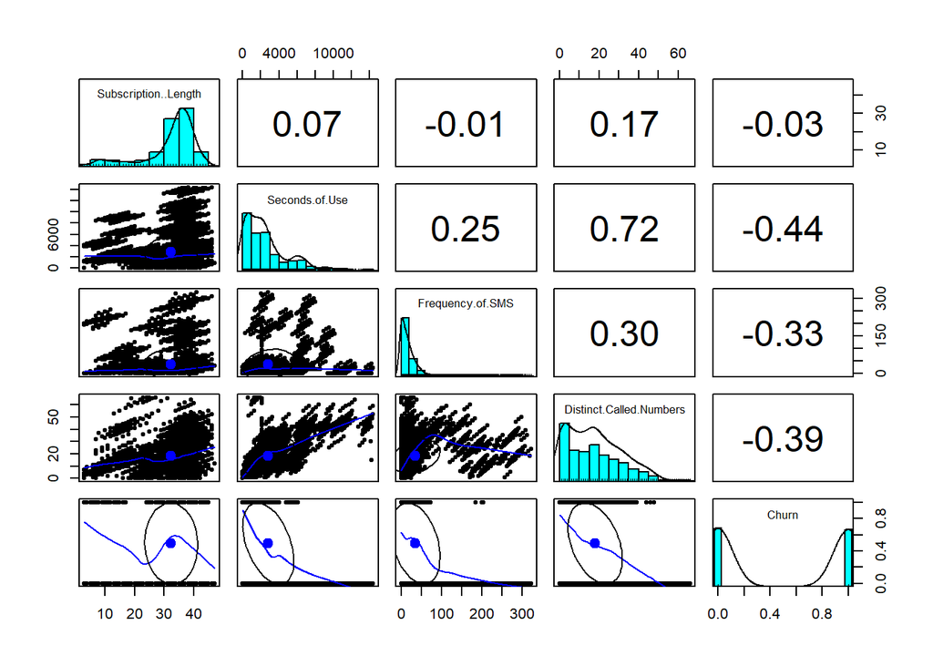

```r
dfs_positives <- c("Subscription..Length", "Seconds.of.Use", "Frequency.of.SMS", "Distinct.Called.Numbers", "Churn")

pairs.panels(dfs[,dfs_positives],)
```

We could associate a higher weight to features that have a higher correlation with churn, for example higher seconds of use seems to definitely impact customer loyalty the most. We’ll do a quick and dirty ranking by hand just to get a quick idea of which value affects our churn the most. If I had more time I would’ve delved deeply into creating a derived feature like this.

Where the first three are clustered pretty closely in terms of correlation, so our final weights would be:

[output not shown]

But we also need to figure out a penalty based on call failure. I’m gonna be honest, complexity can creep in when I’m making a derived feature so I don’t want to suffer at the cost of other parts of the project just to make a derived feature so I can’t expect a 100% accurate estimate.

We can take all of this together and create our own calculation from this, first we create a vector using the calculation, apply a penalty, then we’ll add the vector to our dataframes and tailor them each according to our algorithm later. We go on to use functions more and more now that we have to apply each of our transformations to a specific dataset.

```r
get.satisfaction <- function(df){
Customer.Satisfaction = 0.35 * df$Distinct.Called.Numbers + 0.30 * df$Frequency.of.SMS + 0.25 * df$Seconds.of.Use + 0.1 # 0.1 added to ensure no values are completely zero

# We can divide our variable by call failure
penalty <- ifelse(df$Complains == 0,
                  df$Call..Failure * 0.3,
                  df$Call..Failure * 0.05)

Customer.Satisfaction <- Customer.Satisfaction - penalty

df$Customer.Satisfaction <- Customer.Satisfaction

return(df)
}

dfs <- get.satisfaction(dfs)
dfs.m <- get.satisfaction(dfs.m)
```

Nice! We’ve finally developed our feature. We can tailor our feature as needed when we tailor each dataset towards algorithms. For example, if our derived feature goes through min-max normalization in KNN, we can then treat the feature as a percentage, which can then be binned for logistic regression and random forest.

### KNN Transformations

For KNN, my approach involves mostly retaining the encoding of the dataset as-is in contrast to other algorithms because I expect that within the timeline I have now, this would be the best way to deal with my data.

#### Data partitions

Let’s organize the data we’ll be using in our algorithms here.

```r
dfs.knn <- dfs
dfs.knn_missing <- dfs.m
```

#### Min-max normalization

will still min max normalize our data of course to keep all of our data on the same scale, this will also help make dealing with our derived feature much easier. This can apply to ALL variables in our function.

```r
min_max <- function(x) {
  (x - min(x)) / (max(x) - min(x))
}

dfs.knn[,-11] <- sapply(dfs.knn[,-11], function(x) min_max(x))

dfs.knn_missing[,-11] <- sapply(dfs.knn_missing[,-11], function(x) min_max(x))
```

We now have our data properly prepared for KNN. One benefit of minmaxing is that our customer satisfaction metric also gets normalized into a form that can also be binned for other algorithms, let’s observe the min-max derived feature’s distribution to see if we could bin it into a categorical feature.

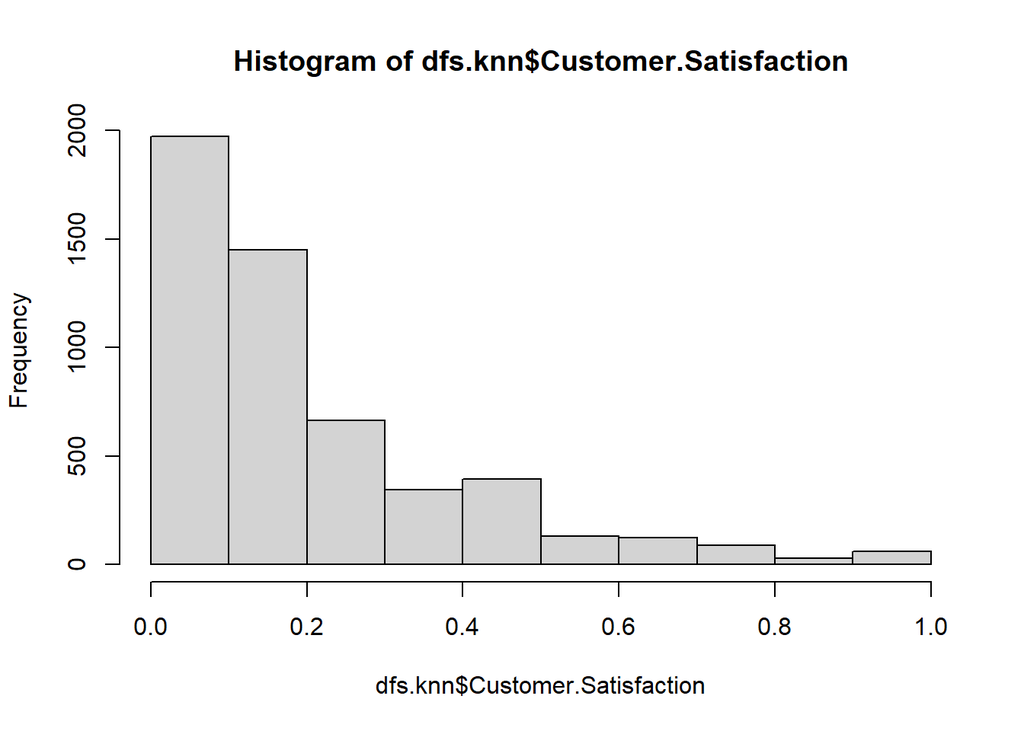

```r
hist(dfs.knn$Customer.Satisfaction)
```

Looks like these customers really aren’t satisfied, huh? This feature looks like it can be easily binned, we’ll address this in Random Forest which works best with binned variables.

### Logistic Regression

For logistic regression, I’ve decided that keeping most of our variables as-is would be fine because complains, tariff plan and status are just binary variables. Charge amount can basically be treated as continuous for logistic regression, while Age is the only variable I took care to encode later on as a categorical factor to be managed by glm() for implicit one-hot encoding. Let’s create datasets as per our need.

Our derived feature, customer satisfaction as a decimal from 0 to 1 was carried forward from the KNN algorithm because of its usefulness, it will be useful for further tailoring a derived feature for random forest later.

```r
dfs.logi <- dfs
dfs.logi_missing <-dfs.m
```

We keep our derived feature from the KNN algorithm, which proves to bea useful metric.

```r
# keep our derived feature, minmaxed before
dfs.logi$Customer.Satisfaction <- dfs.knn$Customer.Satisfaction
dfs.logi_missing$Customer.Satisfaction <- dfs.knn_missing$Customer.Satisfaction

df.nums <- c(df.nums, "Customer.Satisfaction")
```

Why did I use the minmaxed version of Customer.Satisfaction? I feel that it helps working with a metric from 0 to 1 because it’s a more interpretable metric compared to our original formula.

#### Encoding Age for logistic regression

I want to delve deeper with Age as a factor variable for logistic regression. I can’t have too many categoricals for logistic regression because of overfitting so of course this is the only categorical variable I need to one hot encode, we know that complains, tariff plan, status are binary which are satisfactory to logistic regression’s needs. Charge amount won’t have any problems as a numeric variable.

I realized midway through my workflow that both Random forest and logistic regression have VERY DIFFERENT NEEDS in terms of data which I needed to manage. My original plan was to have a binned categorical variable for logistic regression and Random Forest, but I decided to stick with a continuous derived feature for logistic regression.

A small tweak though. I want to change age to a factor so it isn’t treated as ordered and is a factor instead for the algorithm to handle. The only thing is that increases dimensionality, but I want to keep a bit of a compromise between how I want age to be treated and dimensionality, of course we only have one true categorical variable in that case for logistic regression to handle.

```r
dfs.logi$Age <- factor(dfs.logi$Age)
dfs.logi_missing$Age <- factor(dfs.logi_missing$Age)
```

#### Analysis to guide my normalization step

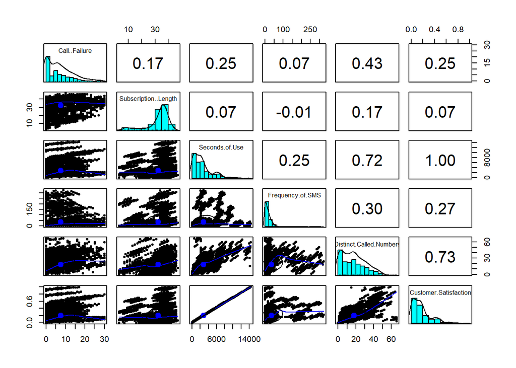

```r
pairs.panels(dfs.logi[,df.nums])
```

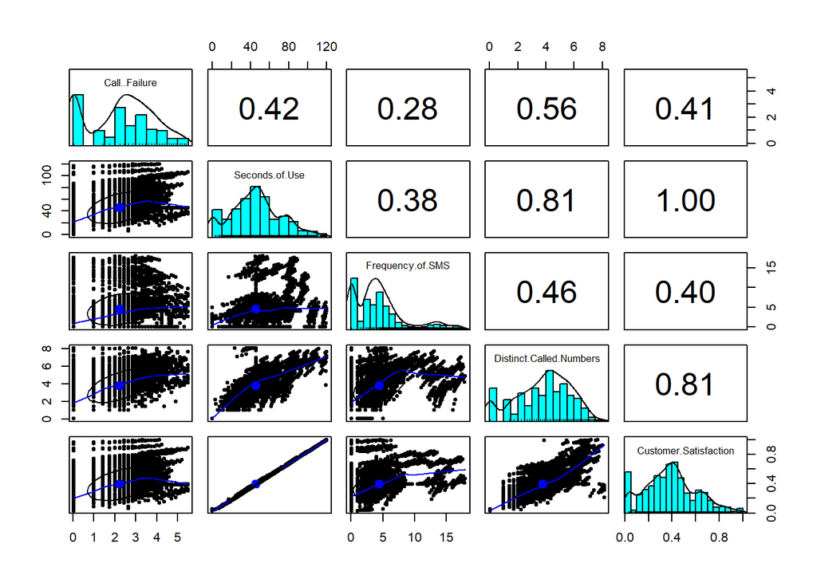

```r
df.num_log <- df.nums

# Remove Subscription length from normalization
df.num_log <- df.nums[-2]

dfs.logi_test <- dfs.logi

dfs.logi_test[,df.num_log] <- lapply(dfs.logi[,df.num_log], function(x) sqrt(x + 0.001))
pairs.panels(dfs.logi_test[,df.num_log])
```

Originally, I had tried this method with a log() transform which introduced colinearities into the data, I did not find that appropriate for the data that we’re working with. You can see here for yourself:

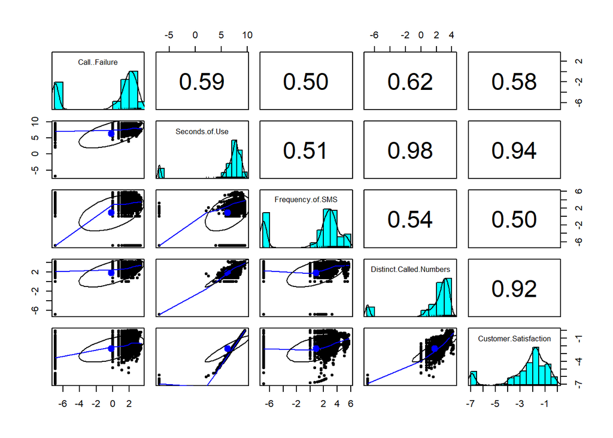

```r
dfs.logi_test[,df.num_log] <- lapply(dfs.logi[,df.num_log], function(x) log(x + 0.001))
pairs.panels(dfs.logi_test[,df.num_log])
```

What conclusions can we draw?

Our analysis showed us that:

- We should drop the derived feature for logistic regression because of colinearity for logistic regression, unfortunately.
- A log transform isn’t the solution, instead we should work with a square root transform. The square root transform does lead to SOME colinearity unfortunately, but it’s more manageable.

#### Final normalization step

Now that we know that a square root transform is the best solution, let’s implement it confidently using the insights we have.

```r
dfs.logi[,df.nums] <- lapply(dfs.logi[,df.nums], function(x) sqrt(x + 0.001))
dfs.logi_missing[,df.nums] <- lapply(dfs.logi_missing[,df.nums], function(x) sqrt(x + 0.001))
```

#### Dropping the derived feature.

Unfortunately, we’ll have to drop our derived feature because of its collinearity, it can still work for other algorithms though. In the future or a more expanded project, I would plan to try and understand how I can manage derived features to reduce colinearity. Perhaps it was how I weighed the calculation which caused the colinearity.

```r
library(dplyr)
dfs.logi <- dfs.logi %>%
  select(-Customer.Satisfaction)

dfs.logi_missing <- dfs.logi_missing %>%
  select(-Customer.Satisfaction)
```

### Random Forest

For random forest, my derived feature is likely going to be the same. I’m reflecting on the fact that if my project were a little bit more ambitious, I would’ve optimized my variables towards a better fit for logistic regression. In this case, random forest would work better with factors for any supposed categoricals. I use “supposed” because sometimes this dataset gives a bit of trouble deciding on whether certain variables should be categorical or numeric, it’s a bit of a gray zone.

Age for example has a very limited set of values, so in that case I consider it categorical for example. It’s a bit of a troubling way of working with data, but I feel that it helps me optimize my variables towards random forest for example. Take what I did in logistic regression for example, why did I introduce a categorical value? I feel that my perspective is driven more by curiosity towards how a certain variable would be handled by an algorithm more than anything.

Throughout my work with this dataset, I keep thinking about how I’m defining my data when it’s so loosely defined in its origins. Categorical or ordinal? Sometimes I also reflect on whether the fact that there is an order to certain variables affects how my algorithms interpret them or not. If I could use one word to describe the problem with this dataset, it would be the word order. How do our algorithms interpret order? If tariff plan and status for example are values from 1 to 2 would our algorithm falsely find a sense of order where there is none? This also is a question that justifies factor encoding.

Reflecting on the same question, one could ask does the order of age matter? Maybe it could be that increasing the age doesn’t really affect Churn as much as the fact that each age group lives a very distinct lifestyle that affects churn in a different way. Age isn’t continuous so it also is justified to be a factor.

#### Introducing Random Forest dataset

Random forest doesn’t expect values to be normalized of course, so we’ll start with all the changes to the shared dataset first, then introduce a binned value which is tailored towards random forest.

```r
dfs.rf <- dfs
dfs.rf_missing <- dfs.m
```

We need to use a dependency we need for a binned feature.

```r
# Pre-derived feature for binning
dfs.rf$Customer.Satisfaction <- dfs.knn$Customer.Satisfaction
dfs.rf_missing$Customer.Satisfaction <- dfs.knn_missing$Customer.Satisfaction
```

Next, we go through the process of creating a new binned feature for random forest. About 5 bins is a bit generous but I thought that it would capture relationships well. It gets a bit tedious copying this for the missing dataset, but ultimately I’m glad that I’m in the flow of things.

```r
dfs.rf <- dfs.rf %>%
  mutate(Satisfaction.bin = case_when(
    Customer.Satisfaction <= 0.2 ~ "Dissatisfied",
    Customer.Satisfaction <= 0.4 ~ "Poor",
    Customer.Satisfaction <= 0.6 ~ "Average",
    Customer.Satisfaction <= 0.8 ~ "Good",
    Customer.Satisfaction <= 1   ~ "Very good",
    TRUE                         ~ NA_character_
  ))

dfs.rf_missing <- dfs.rf_missing %>%
  mutate(Satisfaction.bin = case_when(
    Customer.Satisfaction <= 0.2 ~ "Dissatisfied",
    Customer.Satisfaction <= 0.4 ~ "Poor",
    Customer.Satisfaction <= 0.6 ~ "Average",
    Customer.Satisfaction <= 0.8 ~ "Good",
    Customer.Satisfaction <= 1   ~ "Very good",
    TRUE                         ~ NA_character_
  ))

dfs.rf$Satisfaction.bin <- factor(dfs.rf$Satisfaction.bin,
                                  levels = c("Dissatisfied", "Poor", "Average", "Good", "Very good"),
                                  ordered = TRUE)

dfs.rf_missing$Satisfaction.bin <- factor(dfs.rf_missing$Satisfaction.bin,
                                          levels = c("Dissatisfied", "Poor", "Average", "Good", "Very good"),
                                          ordered = TRUE)

cat("normal dataset\n")
```

```
## normal dataset
```

```r
table(dfs.rf$Satisfaction.bin)
```

```
##
## Dissatisfied         Poor      Average         Good    Very good
##         3422         1010          525          211           90
```

```r
cat("missing dataset\n")
```

```
## missing dataset
```

```r
table(dfs.rf_missing$Satisfaction.bin)
```

```
##
## Dissatisfied         Poor      Average         Good    Very good
##         3451         1052          482          185           88
```

Notice how the magnitude of missing values affected the balance of our derived feature? Our missing dataset has a higher concentration of poor values for example. This reveals a flaw with the mode/mean imputation method where imputing data may bias it towards the center.

#### Tailoring Factor based features

Why would I tailor variables in Random forest to be factors? Well, my idea comes from the fact that Random forest is ultimately an ensemble of decision trees. My logic is that using factors would ultimately lead to a better split for the random forest algorithm. As per our previous discussion, Age would seem the odd one out from our categoricals, but actually I do NOT want to treat age as ordered. For reference, this is what age looks like again.

```
##
##   15   25   30   45   55
##  123 1843 2397  713  182
```

Here’s a hypothesis, Random forest will perform the best out of our algorithms, because of its ensemble nature it’s a great all-rounder algorithm that is flexible to the needs of both numeric and categorical data. This particularly helps when we have a dataset which is structured that way we’ve seen throughout the project, with that “gray zone” between variables.

It’s also more flexible than KNN with handling different scales better.

```
## 'data.frame':    5258 obs. of  5 variables:
##  $ Complains     : int  0 0 0 0 0 0 0 0 0 0 ...
##  $ Tariff.Plan   : int  1 1 1 1 1 1 1 1 1 1 ...
##  $ Status        : int  1 2 1 1 1 1 1 1 1 1 ...
##  $ Age           : int  30 25 30 15 15 30 30 30 30 30 ...
##  $ Charge..Amount: int  0 0 0 0 0 1 0 2 0 1 ...
```

Let’s convert these categorical variables to factors as per our need. We understand that satisfaction_bin has already been converted into a factor.

```r
dfs.rf[, df.cats] <- lapply(dfs.rf[, df.cats], factor)
dfs.rf_missing[, df.cats] <- lapply(dfs.rf_missing[, df.cats], factor)

str(dfs.rf)
```

```
## 'data.frame':    5258 obs. of  13 variables:
##  $ Call..Failure          : num  8 0 10 10 3 11 4 13 7 7 ...
##  $ Complains              : Factor w/ 2 levels "0","1": 1 1 1 1 1 1 1 1 1 1 ...
##  $ Subscription..Length   : num  38 39 37 38 38 38 38 37 38 38 ...
##  $ Charge..Amount         : Factor w/ 11 levels "0","1","2","3",..: 1 1 1 1 1 2 1 3 1 2 ...
##  $ Seconds.of.Use         : num  4370 318 2453 4198 2393 ...
##  $ Frequency.of.SMS       : num  5 7 16 1 2 32 285 144 0 2 ...
##  $ Distinct.Called.Numbers: num  17 4 24 35 33 28 18 43 44 25 ...
##  $ Tariff.Plan            : Factor w/ 2 levels "1","2": 1 1 1 1 1 1 1 1 1 1 ...
##  $ Status                 : Factor w/ 2 levels "1","2": 1 2 1 1 1 1 1 1 1 1 ...
##  $ Age                    : Factor w/ 5 levels "15","25","30",..: 3 2 3 1 1 3 3 3 3 3 ...
##  $ Churn                  : int  0 0 0 0 0 0 0 0 0 0 ...
##  $ Customer.Satisfaction  : num  0.3035 0.0229 0.1724 0.2928 0.1685 ...
##  $ Satisfaction.bin       : Ord.factor w/ 5 levels "Dissatisfied"<..: 2 1 1 2 1 2 1 4 5 2 ...
```

Converting the categoricals to factors also makes them more interpretable as you can see above! Now it’s time to move on to modelling, the difficulty of transitioning to modelling can be in terms of just how much you have to change your way of thinking when you move on to a different stage of the CRISP-DM process. You initially start thinking about your data and how it fits with your algorithms.

#### Remove old derived features

There was also something I forgot, if I have a binned version of Customer Satisfaction, I do not need the numeric version anymore for random forest.

```r
dfs.rf <- dfs.rf %>%
  select(-Customer.Satisfaction)

dfs.rf_missing <- dfs.rf_missing %>%
  select(-Customer.Satisfaction)
```

#### A reflection on Data Preparation

I would like to think about where my journey has taken me. You initially start thinking about your data and how it fits with your algorithms, you think about what insights you can bring out of your data to better fit towards your algorithms If your data doesn’t fit, you still think about how you can make your data fit, what transformations you can do towards your data to improve fit.

Not everything works out, sometimes you don’t have the knowledge for the perfect optimal solution. The truth is, the more I explored my data the more I realized that there’s always more work to do in terms of fitting, more aspects to consider. Under time pressure, you often have to figure out if a specific method would be worth it in terms of complexity too.

The challenge of data preparation helped me think like a data scientist, which was a wonderful skill to gain.

Now we move onto modelling.

# 4 / Modeling

What do I anticipate modelling and evaluation to look like? I anticipate using the holdout method to finally create a fitted KNN, Random forest and logistic regression model.

Since this is the point where things get messy, I want to keep our datasets in mind. One quirk of how we prepare our datasets is that if we want to deploy our model, our ensemble should be deployed by getting a majority vote out of all three of the testing datasets created. This would mean that three separate test datasets that are tailored towards the algorithm would be used for any ensemble prediction.

### Personal reference: Our datasets

```
### KNN datasets

dfs.knn
dfs.knn_missing

### RF Datasets

dfs.rf
dfs.rf_missing

### LR datasets

dfs.logi
dfs.logi_missing
```

### Holdout method or k-fold cross validation?

at this point I was deciding whether to use k-fold cross validation or whether I should use the holdout method to partition my dataset. I decided to use the holdout method instead. Why? In this case I was dealing with multiple datasets.

I’ll have to manage datasets that use missing values and don’t use missing values. I’ll have three different training tasks that I have to work with on top of bagging and an ensemble. That’s one hell of a work pile. If I have roughly 7 hours to finish my work (it’s 11 AM on a Sunday), it’s best that I work with what I know rather than experiment with the unfamiliar.

That said, if I had more time or my project had a few days more, I think that k-fold cross validation would’ve been the best choice for my dataset.

Why would k-fold cross validation have been the better option? Well it would have shown great metrics for my model in all aspects, before I generated synthetic data my dataset was still relatively small, k-fold cross validation could’ve been a great strategy for me to solve class imbalance for example by stratifying my train-test split.

I’ll stick with the holdout method for now though. We’re basically sacrificing model performance in favor of going for an approach that I can thoroughly explain, organize and account for in the given time that I have.

We recall that we are dealing with a binary classification problem, with 1 being churn and 0 being no churn. It is a slight bit unusual because in the case of our business, a 0/negative outcome, in this case churn is favorable right? We also recall that this is called a binary classification problem.

Anyways, let’s go. We’ll be using a 70-30 split because it’s a good balance for our training-test split because there’s a fair amount of data for both training AND evaluation, compared to 80-20 which can get a bit narrow. I emphasize pragmatism throughout my approach to get finished in time.

Of course, when I go forward into creating ensembles I would like to keep the Condorcet Jury theorem in mind, I expect that bagging our models as homogenous learners, then aggregating these bagged learners into a heterogenous vote-based approach will increase the probability that our majority vote is correct closer to 1.

### A caret-heavy approach

When I’m starving for time, I decided that I would emphasize using caret for any of my machine learning needs. This package makes machine learning efficient and reduces any chances for error when I’m in a hurry to finish my deliverable. I want some of the more tedious steps to be a little bit more streamlined, and I like the common shared language that it uses, it’s an exciting challenge.

We’ll also have to consider our bagging approach very soon. While we are using different datasets, I have to consider that I have a very limited amount of time.

#### A quick adjustment: factor our churn variable

Before we do anything, I want to factor our churn column so each algorithm we work with treats our problem as classification

```r
dfs.knn$Churn <- factor(dfs.knn$Churn)
dfs.rf$Churn <- factor(dfs.rf$Churn)
dfs.logi$Churn <- factor(dfs.logi$Churn)
```

## Universal data partitioning

We need to future proof our algorithms in such a way, that our ensemble(Which shows up later) would be able to handle the test/train split that we have.

```r
set.seed(100)

n <- nrow(dfs)
train.ind <- sample(1:n, size=floor(0.7 * n))
test.ind <- setdiff(1:n, train.ind)
```

### KNN

#### Data partitioning

Now we’ll partition our data, each one following) the same pattern. First let’s create partitions for KNN.

```r
library(caret)
train.knn <- dfs.knn[train.ind,]
test.knn <- dfs.knn[test.ind,]
```

I chose a 70-30 split for the reasons outlined previously. We’ll follow with a quick note and continue our work.

#### A quick note on project scope

At this point I had to unfortunately abandon the aspect of my approach that involved handling the missing dataset because I didn’t have enough time, I wanted my focus to remain on ONLY handling our primary dataset because I was having some frustration with repeating each step which wasn’t possible within time constraints. I got a little bit sick with a stomach infection midway through the process so I had to adjust my scope a bit.

“But Saoud, you’ll lose points for abandoning the missing values part of your project.” Considering my circumstances, to guide my brain through the coding process and getting a deliverable, I will always focus on the forest instead of the trees. In this case, the forest or the big picture means getting a deliverable done on time while covering any bases that I can cover.

My mind works in a very specific way sometimes. This means that if I bog myself down in the work of replicating my analysis for missing value based datasets, I’ll miss my goal of actually managing to finish all the other bases like building a working ensemble model with properly bagged datasets.

It’s about being accountable with myself and the professor. If I’m going to finish and hand in the assignment on time with decent quality work, that’s what I’m accountable for, and that’s what I will accomplish by any means necessary while remaining honest and transparent.

I unfortunately also couldn’t fit the use of bagging into my project’s scope because of time constraints so had to stick with going straight towards the final ensemble for my dataset.

#### Fitting KNN - Intro

Now that we have a proper dataset for KNN, our next step will involve fitting the model using KNN, I want to use the caret implementation of knn to train my dataset because I want to streamline the training process, while also allowing for an easier tuning method which doesn’t leave me frustrated. While tuning may have to be sacrificed at times depending on my time, I’ll still keep it in mind when I can.

That said, the good news is that tuning for KNN is fairly straightforward and mostly involves dealing with finding an appropriate value of K.

The caret package can fortunately handle KNN parameter tuning for us. I prefer the caret implementation of KNN over the class() package implementation, mainly because it’s more feature rich and user-friendly.

#### Fitting KNN with the K parameter

We’ll use the caret package implementation to both tune our model to find an appropriate value of K and then fit our k parameter to get some predictions for the test dataset.

Could I have let the algorithm automatically also find a value of k instead of manually specifying a grid?

```r
grid.knn <- expand.grid(k = seq(3, 25, by=2))
```

let’s set up the train control to find an optimal value of k. I noticed one quirk of the caret package which involves its use of k-fold cross validation as the most common method to tune parameters.

When we ultimately do model comparison though, I’d rather proceed with the holdout method for evaluation in our separate model evaluation section. In traincontrol, cv for optimizing the parameter means k-fold crossvalidation, I’ll use 10 folds, which might affect computational cost but it can’t be too bad. It may slow down the runtime as our Rmd gets larger though.

```r
train_ctrl.knn <- trainControl(method = "cv", number = 10)
```

Finally, we fit our KNN model. The more I work with the caret package, the more I feel that I took the right choice by using it for this machine learning project because of its straightforward use case. It has the same sense of beauty and user friendliness you would expect from dplyr for example. The only problem with using a package implementation is that in a better world, I should EXACTLY understand how the model is tuning and what goes on under the hood as a student.

```r
knn.model <- train(Churn ~.,
                   data = train.knn,
                   method = "knn",
                   trControl=train_ctrl.knn
                   )
```

Next, we should plot the K parameter to get a look at what the process looks like, and get an idea of what the optimal value of k looks like.

```
## [1] "The best value of k is 5"
```

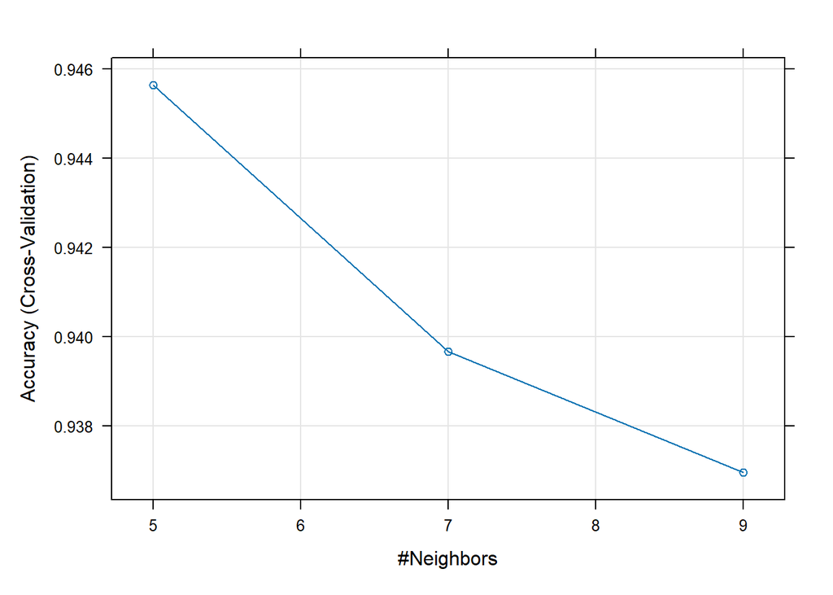

Let’s test how our knn learner predicts

```r
knn.prediction <- predict(knn.model, newdata = test.knn)
```

### Logistic Regression

#### Partitioning dataset

Now, we partition the dataset the same way we did with KNN. You would notice that I’m using the same seed for each model right? I feel that this is valid because my holdout method fundamentally assumes that each model will draw from the same dataset in the same way. If we were to work with bagging for example, that’s when I’d prefer a more random method of sampling.

```r
train.logi <- dfs.logi[train.ind,]
test.logi <- dfs.logi[test.ind,]
```

Now that we’ve properly partitioned out dataset, let’s proceed with fitting our model. In this case using the glm() function instead of caret won’t be much of a problem.

#### Fitting model

Now we need to fit our logistic regression model to the dataset we have. Using the glm() function is pretty much fair game, the only thing is that I’d prefer to do is that right after we’ve fitted the model, I want to work with backwards selection using AIC, which we can do with the step() function.

Let’s fit our model first of course.

```r
library(stats)
model.logi <- glm(Churn~.,data = train.logi, family = binomial(link = "logit"))
summary(model.logi)
```

```
##
## Call:
## glm(formula = Churn ~ ., family = binomial(link = "logit"), data = train.logi)
##
## Coefficients:
##                           Estimate Std. Error z value Pr(>|z|)
## (Intercept)             -13.396658 243.564853  -0.055  0.95614
## Call..Failure             0.483774   0.048516   9.971  < 2e-16 ***
## Complains                 3.941238   0.254857  15.464  < 2e-16 ***
## Subscription..Length     -0.486664   0.059230  -8.217  < 2e-16 ***
## Charge..Amount           -0.437703   0.079480  -5.507 3.65e-08 ***
## Seconds.of.Use           -0.011020   0.004175  -2.639  0.00831 **
## Frequency.of.SMS         -0.133250   0.019952  -6.679 2.41e-11 ***
## Distinct.Called.Numbers  -0.269370   0.053852  -5.002 5.67e-07 ***
## Tariff.Plan              -0.891495   0.423408  -2.106  0.03525 *
## Status                    1.903502   0.158927  11.977  < 2e-16 ***
## Age25                    15.072649 243.564083   0.062  0.95066
## Age30                    14.862193 243.564090   0.061  0.95134
## Age45                    15.027372 243.564122   0.062  0.95080
## Age55                    13.571916 243.564514   0.056  0.95556
## ---
## Signif. codes:  0 '***' 0.001 '**' 0.01 '*' 0.05 '.' 0.1 ' ' 1
##
## (Dispersion parameter for binomial family taken to be 1)
##
##     Null deviance: 5099.7  on 3679  degrees of freedom
## Residual deviance: 2476.5  on 3666  degrees of freedom
## AIC: 2504.5
##
## Number of Fisher Scoring iterations: 15
```

I’m feeling very good about the fit of our model! We’ll probably go more in depth about our model in the evaluation section. While usually AIC is better understood in context of comparison to other models and isn’t much help by itself, the AIC here is generally pretty low compared to previous models that I’ve had experience working with. My only concern to be honest is the potential moderate colinearity we noticed before when we were preparing our dataset for the model. Also notice how a large amount of our features are actually fairly significant.

As per the suggestion from the textbook, encoding Age to a factor allowed our model to automatically one-hot encode Age, but there’s something that I wanted to point out in terms of model fit. Our logistic regression algorithm didn’t consider age to be significant.

We could improve our model by backwards selection using AIC, let’s implement that. I’m also curious as to whether stepwise logistic regression using AIC eliminates age or not.

```r
model.logi <- step(model.logi)
```

```
## Start:  AIC=2504.46
## Churn ~ Call..Failure + Complains + Subscription..Length + Charge..Amount +
##     Seconds.of.Use + Frequency.of.SMS + Distinct.Called.Numbers +
##     Tariff.Plan + Status + Age
##
##                           Df Deviance    AIC
## <none>                         2476.5 2504.5
## - Tariff.Plan              1   2481.3 2507.3
## - Seconds.of.Use           1   2483.5 2509.5
## - Distinct.Called.Numbers  1   2502.6 2528.6
## - Charge..Amount           1   2513.5 2539.5
## - Age                      4   2521.3 2541.3
## - Frequency.of.SMS         1   2529.1 2555.1
## - Subscription..Length     1   2545.5 2571.5
## - Call..Failure            1   2586.3 2612.3
## - Status                   1   2625.7 2651.7
## - Complains                1   3038.1 3064.1
```

#### tuning wishlist

There were a few things for logistic regression which I wanted to tune but ultimately could not because of time reasons. I also wanted to check what the ideal threshold would be for logistic regression to get accurate predictions but this couldn’t be implemented, ideally I would loop through a list of possible thresholds for if-else, from 0.1 to 0.9 to see which value gave the most accurate predictions.

For time purposes, I forgot that I could use the caret implementation which supported regularization and ridge and lasso regression as a hyperparameter.

#### Testing logistic regression.

We can test our algorithm to see how results are output.

I’d like to wrap my logistic regression prediction function to make it a bit easier to use, so that we get 0 and 1 predictions by default.

```r
logi.predict <-function(model, data){
  logi.result <- predict(model, newdata=data, type="response")
  logi.final <- ifelse(logi.result > 0.5, 1, 0)
  return(logi.final)
}

result.a <- logi.predict(model.logi, data = test.logi)

head(result.a)
```

```
## 13 15 22 24 27 32
##  0  0  0  0  0  0
```

```r
tail(result.a)
```

```
## 5239 5242 5244 5246 5249 5254
##    0    1    1    1    1    0
```

### Random Forest

#### Holdout: Dividing dataset

Finally, we do the same data partitioning with Random Forest, I’ve gone over this a fair bit of times so it should be fairly straightforward.

```r
train.rf <- dfs.rf[train.ind,]
test.rf <- dfs.rf[test.ind,]
```

#### Fitting model

Here’s the deal, I want to perform some form of tuning for my implementation of random forest so we’ll use the caret implementation of Random forest. Random forest differs a bit in the sense that it doesn’t have many hyperparameters aside from the number of trees, which we can optimize for accuracy, let’s implement tuning and create a deployable random forest model.

I think that hyperparameter tuning in general could’ve been explored in a LOT more detail if we were to use decision trees. In fact if this project used decision trees instead of random forest, we could have worked on creating an interesting self-implemented version of random forest as a custom ensemble of decision trees. More trees would lead to higher accuracy and would reduce overfitting, but I suspect that we would get diminishing returns at some point, similar to how the k parameter works. In fact it’s pretty interesting how both knn and random forest work on the idea of building consensus and calling a “vote” for classification. Let’s tune the hyperparameter of mtry, this parameter specifically refers to the number of variables sampled at each split when the decision tree is being built.

```r
rf.grid <- expand.grid(mtry =seq(1, 15))
```

I think that caret has much to be explored actually, in a future project for example I’d love to look further into tuning decision trees for example, because they tend to be the most “interactive” model in a sense.

Next, let’s set our train control. While we could use cross validation, The only thing is that I anticipate random forest to be fairly computationally expensive. I had to tweak the validation parameters because using number = 10 took a very long time. I also realized that random forest has out of the box tuning which is better than cross-validation when it comes to using computational resources.

```r
train_ctrl.rf <- trainControl(method = "oob", number = 5)
```

Finally, we can implement this into a proper model. I used an arbitrary number of trees as 100 to balance the computational time that random forest takes with accuracy. While I didn’t have much time, we could have also plotted the number of trees against accuracy to further discover a trend for example.

```r
rf_model <- train(Churn ~ .,
                  data = train.rf,
                  method = "rf",
                  trControl = train_ctrl.rf,
                  tuneGrid = rf.grid,
                  ntree=100)
print(rf_model)
```

```
## Random Forest
##
## 3680 samples
##   11 predictor
##    2 classes: '0', '1'
##
## No pre-processing
## Resampling results across tuning parameters:
##
##   mtry  Accuracy   Kappa
##    1    0.8171196  0.6352374
##    2    0.8777174  0.7561111
##    3    0.9081522  0.8168654
##    4    0.9236413  0.8476847
##    5    0.9470109  0.8942037
##    6    0.9644022  0.9288664
##    7    0.9709239  0.9418915
##    8    0.9766304  0.9532829
##    9    0.9766304  0.9532818
##   10    0.9769022  0.9538245
##   11    0.9779891  0.9559953
##   12    0.9782609  0.9565381
##   13    0.9798913  0.9597958
##   14    0.9782609  0.9565391
##   15    0.9796196  0.9592529
##
## Accuracy was used to select the optimal model using the largest value.
## The final value used for the model was mtry = 13.
```

We can plot the random forest model to see the optimal level of the mtry parameter.

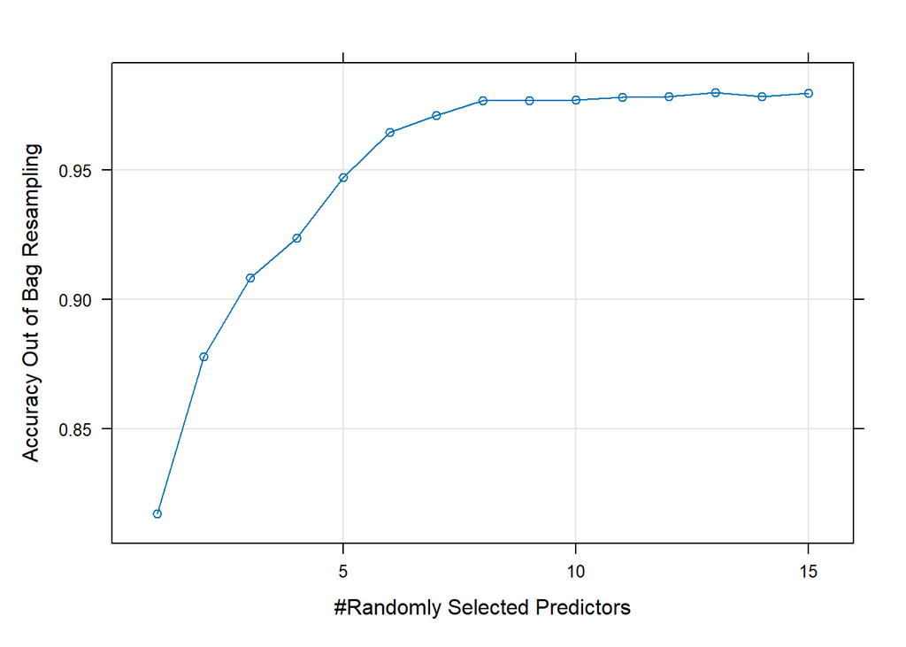

```r
plot(rf_model)
```

I don’t see any need to bag the random forest algorithm because it’s already an ensemble model that bags several decision trees together. A better adjustment would be the number of trees instead because random forest performs bagging by default.

### Building the Ensemble

Finally, here we build a heterogenous ensemble prediction function here from the models that we have. Since our work can get a bit messy, I want to work in such a manner that we use a list for both our test sets and our models.

```r
classifier <- list(knn.model, model.logi, rf_model)

test <- list(test.knn, test.logi, test.rf)
```

Next, using these two lists we can create an ensemble classifier for predictions. I’ve noticed that the classifier function runs fine the first time around, but if I rerun all code blocks again, there will be a mismatch between the rows for logistic regression and KNN in the classifier. This has something to do with a single row being dropped from test.logi for whatever reason. It still works the first time around, but another trial run seems to affect the dataset so to evaluate this model I have to close my Rmd and then open it again, I hope this doesn’t affect knitting.

```r
ensemble_predict <- function(models, test_sets) {
  predictions <- list()

  for (i in seq_along(models)) {
    model <- models[[i]]
    test_data <- test_sets[[i]]

    if ("glm" %in% class(model)) {
      preds <- logi.predict(model, test_data)
    } else {
      preds <- predict(model, newdata = test_data)
      preds <- as.numeric(as.character(preds))
    }

    predictions[[i]] <- preds
  }

  pred_df <- as.data.frame(predictions)

  majority_vote <- apply(pred_df, 1, function(row) {
    as.numeric(names(sort(table(row), decreasing = TRUE)[1]))
  })

  return(majority_vote)
}

e.predictions <- ensemble_predict(classifier, test)

head(e.predictions)
```

```
## 13 15 22 24 27 32
##  0  0  0  0  0  0
```

```r
tail(e.predictions)
```

```
## 5239 5242 5244 5246 5249 5254
##    1    1    1    1    1    1
```

# 5 / Evaluation

Now that we have our models as required, we’ll evaluate both the models and the ensemble.

#### Evaluating individual models and comparison

For this section, I wanted to use caret’s confusion matrix function to better understand how each of my models faired. Remember, the models that we’re working with are knn.model, model.logi, rf_model. I want to evaluate each model in terms of metrics like accuracy and F1-score. Let’s evaluate our KNN data first.

#### Evaluating KNN

```r
prediction.knn <- predict(knn.model, newdata = test.knn)

confusion.knn <- confusionMatrix(prediction.knn, test.knn$Churn, positive = "1")

confusion.knn$byClass
```

```
##          Sensitivity          Specificity       Pos Pred Value
##            0.9800995            0.9173127            0.9248826
##       Neg Pred Value            Precision               Recall
##            0.9779614            0.9248826            0.9800995
##                   F1           Prevalence       Detection Rate
##            0.9516908            0.5095057            0.4993663
## Detection Prevalence    Balanced Accuracy
##            0.5399240            0.9487061
```

```r
confusion.knn$table
```

```
##           Reference
## Prediction   0   1
##          0 710  16
##          1  64 788
```

I chose to focus on the byclass metrics for each model because they specifically talk about the results that I’m most interested in. Overall the algorithm fared pretty well in terms of true positives and true negatives, this was a pleasant surprise compared to how we started in our original practicum with a fairly imbalanced model which would tend to overpredict towards the positive class.

Of course to really better understand how this model fared, we should also compare it to the predictions from other models too.

#### Evaluating logistic regression

```r
prediction.logistic <- logi.predict(model.logi,test.logi)

confusion.logistic <- confusionMatrix(factor(prediction.logistic), test.logi$Churn, positive = "1")

confusion.logistic$byClass
```

```
##          Sensitivity          Specificity       Pos Pred Value
##            0.8594527            0.8604651            0.8648310
##       Neg Pred Value            Precision               Recall
##            0.8549422            0.8648310            0.8594527
##                   F1           Prevalence       Detection Rate
##            0.8621335            0.5095057            0.4378961
## Detection Prevalence    Balanced Accuracy
##            0.5063371            0.8599589
```

```r
confusion.logistic$table
```

```
##           Reference
## Prediction   0   1
##          0 666 113
##          1 108 691
```

Our logistic regression fared much less well in several metrics compared to our KNN model. This is to be somewhat expected to some extent because my logistic regression algorithm was much harder to fit to my dataset, there were a lot of different considerations and different types of experimentation that I had to do with logistic regression. I was trying to fit a categorical feature to the algorithm for example which may not have been the best choice. The one normalization method that could manage colinearity didn’t normalize the data perfectly to the requirements of the algorithm as KNN did, and I could have adjusted hyperparameters much better.

```r
prediction.rf <- predict(rf_model, newdata = test.rf)

confusion.rf <- confusionMatrix(factor(prediction.rf), test.rf$Churn, positive = "1")

confusion.rf$byClass
```

```
##          Sensitivity          Specificity       Pos Pred Value
##            0.9937811            0.9689922            0.9708384
##       Neg Pred Value            Precision               Recall
##            0.9933775            0.9708384            0.9937811
##                   F1           Prevalence       Detection Rate
##            0.9821758            0.5095057            0.5063371
## Detection Prevalence    Balanced Accuracy
##            0.5215463            0.9813867
```

```r
confusion.rf$table
```

```
##           Reference
## Prediction   0   1
##          0 750   5
##          1  24 799
```

#### Models versus the ensemble.

Finally, we compare our models to the ensemble. This part of the evaluation can be a little bit unreliable because of a bug that’s apparent in my ensemble code, even though it still works in certain contexts. The way the ensemble works may have to be a bit tweaked, I have to take the final predictions the ensemble has already put in, then use the labels from the original dataset with the testing indices to evaluate this model, a bit of a rough workaround, but of course we expect the class labels to be the same for each dataset right?

```r
test.ensemble <- test.knn$Churn
class(test.ensemble)
```

```
## [1] "factor"
```

```r
# see prediction in modelling section
confusion.ensemble <- confusionMatrix(factor(e.predictions), test.ensemble, positive = "1")

confusion.ensemble$byClass
```

```
##          Sensitivity          Specificity       Pos Pred Value
##            0.9850746            0.9418605            0.9462366
##       Neg Pred Value            Precision               Recall
##            0.9838057            0.9462366            0.9850746
##                   F1           Prevalence       Detection Rate
##            0.9652651            0.5095057            0.5019011
## Detection Prevalence    Balanced Accuracy
##            0.5304183            0.9634675
```

```r
confusion.ensemble$table
```

```
##           Reference
## Prediction   0   1
##          0 729  12
##          1  45 792
```

The following code above is what I ultimately was attempting to do to evaluate my ensemble. For whatever reason the original ensemble function actually output proper data and predictions. I would think that there is some troubleshooting to do in terms of managing my ensemble but ultimately could not before the deadline. If my ensemble worked, I anticipate that the process of creating a majority vote would lead to better performance in ensemble compared to the rest of the datasets. My only concern would be if the ensemble would perform better overall compared to random forest for example. While other algorithms in the ensemble can compensate, logistic regression for example would compromise the ensemble’s performance overall compared to other algorithms.

# 6 / Deployment.

While most parts of this Rmd have been thoroughly well documented and show a good effort at modelling, I feel that the ensemble portion of my project compromises how deployable my classification approach is. I’m planning to work with this project further over the summer to make further improvements on my approach and how the data is handled, for example for the models in this document to be considered actually deployable, here are some particular things I would like to fix:

- I would like to opt for a k-fold cross validation approach
- I would like to improve how the class balance is addressed, and work with an improved version of SMOTE that samples my data better.
- I would like to improve the fit of my logistic regression algorithm towards my dataset.
- I would like to implement bagging properly for KNN and logistic regression, which would lead to a better fit overall for both algorithms and a better ensemble model overall
- I would also need to implement a proper bug free ensemble, this ensemble would take a list of a models and a list of testing data to generate a proper prediction which could be evaluated.
- I would like to improve my ensemble in such a way that it automatically applies any transformations to new data so that it can easily be fit for applications in the telecom industry.

# 7 / References

- Iranian Churn [Dataset]. (2020). UCI Machine Learning Repository. https://doi.org/10.24432/C5JW3Z, https://archive.ics.uci.edu/dataset/563/iranian+churn+dataset
- Uzoukwu, Jeffery. “An Analysis of Iranian Telecom Churn Rate.” Medium, 29 June 2024, https://medium.com/@jeffchi21/an-analysis-of-iranian-telecom-churn-rate-2d8eece16bad.
- RPubs - How to Handle Imbalanced Datasets. https://rpubs.com/DeclanStockdale/799284. Accessed 17 Apr. 2025.
- OpenAI. (2023). ChatGPT (Mar 14 version) [Large language model].

# Disclosure of chatGPT use

I was reliant on chatGPT for several aspects of the project, but my intention was to use it as an accomodation to get me through the project throughout my work timeline. I have a strong interest in promoting ethical use of ChatGPT as fundamentally a learning tool. At times I can recognize its weaknesses and my experience with its use during the semester have shown me that when used as a crutch, it can somewhat disrupt the learning experience at times.

In the interest of being completely transparent and honest about my work, I will post links to all the chats that were used throughout the practicum because of the importance of transparency in data science. please find them below:

- https://chatgpt.com/share/6805b67a-d508-800d-a198-81f09f27dda9
- https://chatgpt.com/share/6805b6e9-3550-800d-963f-698e5f41a615
- https://chatgpt.com/share/6805b71f-ea60-800d-963a-1c25ce3e6c31
- https://chatgpt.com/share/6805b748-c410-800d-ada1-71fd01ee77e3
- https://chatgpt.com/share/6805b748-c410-800d-ada1-71fd01ee77e3